# Devoir final de R

Kerencia

2025-05-12

# Chargement des packages nécessaires

```r
#Installation et importation des packages

packages <- c("dplyr","flextable","officer","officedown","tidyverse", "haven", "gtsummary")


for (package in packages) {
  if (!requireNamespace(package, quietly = TRUE)) {   # Vérifie si le package n'est pas encore installé
    install.packages(package)
  }
  library(package, character.only = TRUE) # nom du package en nom ou chaine de caractère ()
}
```

# I Importation des Bases

```r
base_individu<-haven::read_dta("../Base_Individus.dta")
base_principale<-read_dta("../Documents/Base_Principale.dta")
```

## Nettoyage des noms de colonnes

```r
# Nettoyage des noms de variables de la base individu avec clean_names


# Application de clean_names
base_clean_individu <- base_individu %>% janitor::clean_names()

# Options disponibles pour clean_names
# "snake_case" (par défaut)
snake <- base_individu %>% janitor::clean_names(case = "snake")
```

```r
# Nettoyage des noms de variables de la base principale avec clean_names

# Application de clean_names
base_clean_principale <- base_principale %>% janitor::clean_names()

# Options disponibles pour clean_names
# "snake_case" (par défaut)
snake <- base_principale%>% janitor::clean_names(case = "snake")

base_individu<-base_clean_individu
base_principale<-base_clean_principale
```

## Dimensions des bases

```r
# Dimensions de la base
dim(base_individu)
```

```
[1] 22092   144
```

```r
dim(base_principale)
```

```
[1] 3058 1312
```

## Vérification des valeurs manquantes

```r
# Calculer le nombre de valeurs manquantes par variable (colonne)
print("Valeurs manquante base individu")
NA_individu <- colSums(is.na(base_individu))

print("Valeurs manquante base principale")
NA_principale <- colSums(is.na(base_principale))
```

Nous constatons que les deux bases présentent beaucoup de valeurs manquantes et ceci sur plusieurs variables. Nous ne disposons pas d’ assez d’ informations pour faire l’ imputation mais nous suspectons la presence de colonne vide dans la base principale et dans la base individu. Le code suivant nous eclaira dessus :

```r
# Compter le nombre de colonnes entièrement vides (toutes les valeurs sont NA)
sum(sapply(base_individu, function(col) all(is.na(col))))
```

```
[1] 0
```

```r
sum(sapply(base_principale, function(col) all(is.na(col))))
```

```
[1] 68
```

On remarque donc comme prévu que dans la base principale il y a 68 colones vides mais dans la base individu y’en a pas .De ce fait, nous allons suprrimer les colonnes vides dans la base principales.

```r
base_principale <- janitor::remove_empty(base_principale, which = "cols")
```

Verifions que ces colonnes ont bien ete supprimées :

```r
sum(sapply(base_principale, function(col) all(is.na(col))))
```

```
[1] 0
```

Il n’ y a éffectivement plus de colonnes vides dans la base principale.

# Pyramide des ages des individus

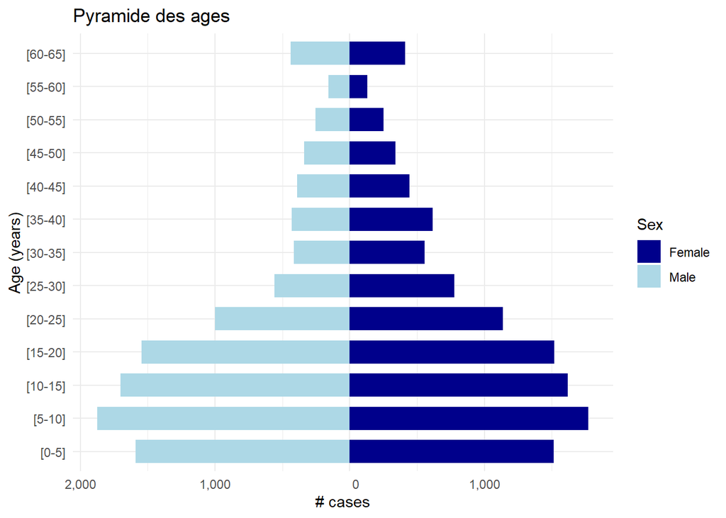

```r
# Charger les bibliothèques nécessaires
library(ggplot2)
library(dplyr)

# Supprimons les valeurs manquantes
base_individu <- base_individu %>% filter(!is.na(age_years))

# Créer des groupes d'âge
base_individu$age_group <- cut(base_individu$age_years,
                               breaks = seq(0, 85, by = 5),
                               right = FALSE,
                               labels = c("[0-5]", "[5-10]", "[10-15]", "[15-20]",
                                         "[20-25]", "[25-30]", "[30-35]", "[35-40]",
                                         "[40-45]", "[45-50]", "[50-55]", "[55-60]",
                                         "[60-65]", "[65-70]", "[70-75]", "[75-80]",
                                         "[80-85]"))

# Comptons le nombre d'individus par groupe d'âge et sexe
# Filtrer pour ne garder que les entrées valides (pas de NA)
age_sex_distribution <- base_individu %>%
  filter(!is.na(hh_02) & hh_02 %in% c(1, 2)) %>%  # Garder seulement les codes valides
  group_by(age_group, hh_02) %>%
  summarise(count = n(), .groups = "drop") %>%
  mutate(
    gender = case_when(
      hh_02 == 1 ~ "Male",
      hh_02 == 2 ~ "Female"
    ),
    count = ifelse(gender == "Male", -count, count)
  )

# Créer la pyramide des âges
ggplot(age_sex_distribution, aes(x = age_group, y = count, fill = gender)) +
  geom_bar(stat = "identity", width = 0.7) +
  coord_flip() +
  scale_fill_manual(values = c("Male" = "lightblue", "Female" = "darkblue"),
                   name = "Sex") +
  scale_y_continuous(labels = function(x) format(abs(x), big.mark = ",")) +
  labs(title = "Pyramide des ages", x = "Age (years)", y = "# cases") +
  geom_vline(xintercept = 0, color = "black", linetype = "dashed") +
  theme_minimal()
```

Cette pyramide des âges montre une population très jeune, avec une majorité d’individus dans les tranches de 0 à 20 ans. La répartition entre hommes et femmes est globalement équilibrée, avec un léger avantage féminin dans certaines tranches. La population diminue progressivement avec l’âge, indiquant une forte natalité et une espérance de vie plus courte.

```r
base_individu <- base_individu %>%
  mutate(across(where(is.character), ~iconv(.x, from = "", to = "UTF-8", sub = " ")))
```

```r
library(dplyr)
library(janitor)
library(gtsummary)
library(labelled)

# Nettoyage de l'encodage
base_individu <- base_individu %>%
  mutate(across(where(is.character), ~iconv(.x, from = "", to = "UTF-8", sub = " ")))

# Recode des facteurs
base_individu <- base_individu %>%
  to_factor()

# Création du tableau
table1 <- base_individu %>%
  select(age_years, hh_02, hh_08, intro_07_1) %>%
  tbl_summary(
    by = intro_07_1,
    statistic = list(
      all_continuous() ~ "{mean} ({min}, {max})",
      all_categorical() ~ "{p}%"
    ),
    digits = all_continuous() ~ 1,
    missing = "no"
  ) %>%
  add_p(
    test = list(
      age_years ~ "wilcox.test",
      hh_02 ~ "chisq.test",
      hh_08 ~ "fisher.test"
    )
  ) %>%
  modify_header(label ~ "**Caracteristiques du chef de menage**") %>%
  bold_labels()

# Affichage
table1
```

| **Caracteristiques du chef de menage** | **Refugees** N = 14,344<sup>1</sup> | **Asylum-seekers** N = 0<sup>1</sup> | **Host community North** N = 7,453<sup>1</sup> | **Returnees** N = 0<sup>1</sup> | **p-value**<sup>2</sup> |
| --- | --- | --- | --- | --- | --- |
| Age in completed years |  |  |  |  |  |
| 00 | 3.2% | NA% | 3.4% | NA% |  |
| 01 | 3.3% | NA% | 3.4% | NA% |  |
| 02 | 4.3% | NA% | 3.1% | NA% |  |
| 03 | 3.8% | NA% | 3.6% | NA% |  |
| 04 | 3.8% | NA% | 3.4% | NA% |  |
| 05 | 2.8% | NA% | 1.9% | NA% |  |
| 06 | 3.5% | NA% | 4.0% | NA% |  |
| 07 | 3.0% | NA% | 3.7% | NA% |  |
| 08 | 3.6% | NA% | 3.8% | NA% |  |
| 09 | 3.3% | NA% | 2.8% | NA% |  |
| 10 | 3.1% | NA% | 3.5% | NA% |  |
| 11 | 3.1% | NA% | 2.1% | NA% |  |
| 12 | 3.2% | NA% | 3.3% | NA% |  |
| 13 | 3.3% | NA% | 2.4% | NA% |  |
| 14 | 3.1% | NA% | 2.3% | NA% |  |
| 15 | 3.2% | NA% | 3.2% | NA% |  |
| 16 | 2.4% | NA% | 2.2% | NA% |  |
| 17 | 2.9% | NA% | 2.3% | NA% |  |
| 18 | 3.0% | NA% | 3.2% | NA% |  |
| 19 | 2.3% | NA% | 2.1% | NA% |  |
| 20 | 2.2% | NA% | 3.0% | NA% |  |
| 21 | 1.6% | NA% | 1.2% | NA% |  |
| 22 | 1.8% | NA% | 1.9% | NA% |  |
| 23 | 1.9% | NA% | 1.7% | NA% |  |
| 24 | 1.1% | NA% | 1.1% | NA% |  |
| 25 | 1.4% | NA% | 2.3% | NA% |  |
| 26 | 1.1% | NA% | 1.0% | NA% |  |
| 27 | 1.0% | NA% | 0.9% | NA% |  |
| 28 | 1.2% | NA% | 1.4% | NA% |  |
| 29 | 0.7% | NA% | 0.9% | NA% |  |
| 30 | 1.1% | NA% | 2.4% | NA% |  |
| 31 | 0.9% | NA% | 0.5% | NA% |  |
| 32 | 0.7% | NA% | 0.7% | NA% |  |
| 33 | 0.8% | NA% | 0.4% | NA% |  |
| 34 | 0.6% | NA% | 0.4% | NA% |  |
| 35 | 1.3% | NA% | 1.9% | NA% |  |
| 36 | 1.2% | NA% | 0.7% | NA% |  |
| 37 | 0.8% | NA% | 0.6% | NA% |  |
| 38 | 1.0% | NA% | 1.2% | NA% |  |
| 39 | 0.8% | NA% | 0.6% | NA% |  |
| 40 | 1.0% | NA% | 2.0% | NA% |  |
| 41 | 0.8% | NA% | 0.2% | NA% |  |
| 42 | 0.5% | NA% | 0.4% | NA% |  |
| 43 | 0.7% | NA% | 0.6% | NA% |  |
| 44 | 0.4% | NA% | 0.3% | NA% |  |
| 45 | 0.9% | NA% | 2.1% | NA% |  |
| 46 | 0.8% | NA% | 0.3% | NA% |  |
| 47 | 0.3% | NA% | 0.3% | NA% |  |
| 48 | 0.4% | NA% | 0.5% | NA% |  |
| 49 | 0.4% | NA% | 0.2% | NA% |  |
| 50 | 0.7% | NA% | 2.0% | NA% |  |
| 51 | 0.6% | NA% | 0.1% | NA% |  |
| 52 | 0.2% | NA% | 0.2% | NA% |  |
| 53 | 0.3% | NA% | 0.3% | NA% |  |
| 54 | 0.2% | NA% | 0.1% | NA% |  |
| 55 | 0.3% | NA% | 0.8% | NA% |  |
| 56 | 0.4% | NA% | 0.2% | NA% |  |
| 57 | 0.2% | NA% | <0.1% | NA% |  |
| 58 | 0.1% | NA% | 0.1% | NA% |  |
| 59 | 0.2% | NA% | <0.1% | NA% |  |
| 60 or more | 3.2% | NA% | 4.7% | NA% |  |
| Sex |  |  |  |  | 0.3 |
| Male | 49% | NA% | 50% | NA% |  |
| Female | 51% | NA% | 50% | NA% |  |
| What is [your/name's] present marital status? |  |  |  |  |  |
| monogamous/married | 35% | NA% | 44% | NA% |  |
| polygamous/married | 4.7% | NA% | 4.2% | NA% |  |
| non-formal union | 0.3% | NA% | 0.2% | NA% |  |
| separated | 2.2% | NA% | 1.1% | NA% |  |
| divorced | 1.4% | NA% | 0.6% | NA% |  |
| widow or widower | 2.8% | NA% | 3.3% | NA% |  |
| never married | 54% | NA% | 47% | NA% |  |

<sup>1</sup> %  
<sup>2</sup> Pearson’s Chi-squared test

# 3)l’indice d’affluence

L’indice d’affluence (ou crowding index) permet d’évaluer le niveau de surpeuplement dans un logement. Il est calculé en divisant le nombre total de membres du ménage par le nombre de pièces disponibles (hors cuisine, toilettes et couloirs). Cet indicateur est souvent utilisé comme un proxy de précarité résidentielle, car un indice élevé peut refléter des conditions de vie surpeuplées, parfois associées à des situations de vulnérabilité économique ou sanitaire.

## 3a) Calculer le nombre d’individus par ménage

Avant d’étudier le surpeuplement, il est nécessaire de connaître combien de personnes vivent dans chaque ménage. Cette étape consiste à regrouper les individus selon leur identifiant de ménage et à compter leur nombre, ce qui permet de créer une nouvelle variable : le nombre d’individus par ménage.

```r
library(dplyr)

# Nombre d'individus par ménage
ind_par_menage <- base_individu%>%
  group_by(id) %>%
  summarise(nb_membres = n())%>%
  ungroup()
```

## 3b)Statistiques descriptives sur le nombre d’ individu par menage

Une fois le nombre d’individus par ménage calculé, il est important d’en étudier la distribution. Cela inclut la moyenne, l’écart-type, les valeurs extrêmes, etc. Ces statistiques permettent de décrire la taille moyenne des ménages et leur dispersion.

```r
library(dplyr)
library(tibble)

# Calcul des statistiques de nb_membres
stats <- ind_par_menage %>%
  summarise(
    Moyenne = mean(nb_membres),
    Ecart_type = sd(nb_membres),
    Min = min(nb_membres),
    Max = max(nb_membres)
  )

# Création du tableau final à 2 lignes et 5 colonnes
tableau_stats <- tibble(
  Variable = "Nombre d'individus par menage",
  Moyenne = round(stats$Moyenne, 1),
  Ecart_type = round(stats$Ecart_type, 1),
  Min = stats$Min,
  Max = stats$Max
)
print(tableau_stats)
```

```
# A tibble: 1 × 5
  Variable                      Moyenne Ecart_type   Min   Max
  <chr>                           <dbl>      <dbl> <int> <int>
1 Nombre d'individus par menage     7.1        3.1     1    17
```

**Résumé du tableau** : Le nombre moyen d’individus par ménage est de 7,1, avec un écart-type de 3,1. Les tailles des ménages varient de 1 à 17 personnes, indiquant une grande diversité.

## 3c)Statistiques descriptives sur la variable renseigant le nombre de pieces du menage

Pour calculer l’indice d’affluence, on a aussi besoin de la variable représentant le nombre de pièces dans le logement. Cette étape consiste à décrire cette variable pour identifier s’il existe des cas problématiques (valeurs nulles, extrêmes ou manquantes).

```r
# Chargement des librairies utiles

library(tidyr)
library(e1071)
# Résumé statistique de la variable 'hh14' (nombre de pièces par ménage)
resume_pieces <- base_principale %>%
  summarise(
    Min          = min(hh14, na.rm = TRUE),
    Max          = max(hh14, na.rm = TRUE),
    Moy          = mean(hh14, na.rm = TRUE),
    Mediane      = median(hh14, na.rm = TRUE),
    Ecart_type   = sd(hh14, na.rm = TRUE),
    Var          = var(hh14, na.rm = TRUE),
    Q25          = quantile(hh14, probs = 0.25, na.rm = TRUE),
    Q75          = quantile(hh14, probs = 0.75, na.rm = TRUE),
    Interval_IQR = IQR(hh14, na.rm = TRUE),
    Asymetrie    = skewness(hh14, na.rm = TRUE),
    Aplatissement = kurtosis(hh14, na.rm = TRUE)
  ) %>%
  pivot_longer(cols = everything(),
               names_to = "Indicateur",
               values_to = "Résultat")
print(resume_pieces)
```

```
# A tibble: 11 × 2
   Indicateur    Résultat
   <chr>            <dbl>
 1 Min               1
 2 Max              21
 3 Moy               2.39
 4 Mediane           2
 5 Ecart_type        1.32
 6 Var               1.75
 7 Q25               2
 8 Q75               3
 9 Interval_IQR      1
10 Asymetrie         2.39
11 Aplatissement    16.8
```

## 3d) Calcul l’indice d’affluence ou crowding index**

L’indice d’affluence est obtenu en divisant le nombre d’individus par le nombre de pièces. Afin d’éviter une division par zéro, il est recommandé de filtrer ou d’encoder correctement les cas où le nombre de pièces est nul. Cette variable quantitative continue servira ensuite à catégoriser les ménages selon leur niveau de surpeuplement.

```r
sum(base_principale$hh_14 == 0, na.rm = TRUE)
```

```
[1] 0
```

Donc les observations du nombre de pieces du menages sont tous positif. Calcul de l’indice d’ affluence :

```r
base_principale<-left_join(base_principale,ind_par_menage,"id")
# Création de la variable crowding index
base_principale <- base_principale %>%
  mutate(crowding_index = nb_membres / hh14)
```

## 3e)proportion de menage dont le crowding index est: <1, 1<= crowding_index<2, 2<= crowding_index<3 et >=3**

Pour rendre l’indice d’affluence plus interprétable, on le regroupe souvent en classes :

< 1 (non surpeuplé)

entre 1 et < 2 (léger surpeuplement)

entre 2 et < 3 (modéré)

≥ 3 (sévère)

On présente ensuite la répartition des ménages dans ces catégories sous forme de tableau de fréquences et de proportions.

```r
library(dplyr)
library(flextable)

# Catégoriser le crowding index
base_principale <- base_principale %>%
  mutate(crowding_cat = case_when(
    crowding_index < 1 ~ "<1",
    crowding_index >= 1 & crowding_index < 2 ~ "1-2",
    crowding_index >= 2 & crowding_index < 3 ~ "2-3",
    crowding_index >= 3 ~ ">=3"
  ))

# Afficher les proportions
base_principale %>%
  count(crowding_cat) %>%
  mutate(proportion = round(100 * n / sum(n), 1)) %>%  # Calcul des proportions
  flextable::qflextable() %>%  # Utiliser qflextable pour générer la table
  fontsize(size = 9, part = "all") %>%
  font(fontname = "Times New Roman", part = "all") %>%
  bg(bg = "#D6EAF8", part = "header") %>%
  align(align = "center", part = "header") %>%
  align(align = "left", j = 1) %>%
  autofit() %>%
  width(width = 1, j = 1) %>%
  set_table_properties(layout = "autofit") %>%
  add_footer_lines("Source: Calculs de l'auteur bases sur les donnees de l'enquete.") %>%
  border(border = fp_border(color = "black", width = 1), part = "all") %>%
  hline(border = fp_border(color = "black", width = 1)) %>%
  vline(border = fp_border(color = "black", width = 1)) %>%
  hline_top(border = fp_border(color = "black", width = 2)) %>%
  hline_bottom(border = fp_border(color = "black", width = 2))
```

| crowding_cat | n | proportion |
| --- | --- | --- |
| 1-2 | 476 | 15.6 |
| 2-3 | 737 | 24.1 |
| <1 | 68 | 2.2 |
| >=3 | 1,771 | 57.9 |
|  | 6 | 0.2 |

Source: Calculs de l'auteur bases sur les donnees de l'enquete.

## 3f)Statistiques suivant que le menage soit un refugie ou un member de la communaute d’acceuil

Enfin, on peut comparer le niveau de surpeuplement entre réfugiés et communautés hôtes. Cela permet d’évaluer s’il existe une différence structurelle dans les conditions d’habitat entre ces deux groupes, à l’aide de tableaux croisés et de tests statistiques.

```r
# Tableau de résumé avec gtsummary et p-values

table_crowding_grouped <- base_principale%>%
  select(intro_07_1, crowding_cat) %>%
  tbl_summary(
    by = intro_07_1,
    label = list(crowding_cat ~ "Categories du Crowding Index"),
    statistic = list(all_categorical() ~ "{n} ({p}%)"),
    missing = "no"
  ) %>%
  add_p(test = all_categorical() ~ "chisq.test") %>%
  modify_header(label ~ "*Categorie*") %>%
  modify_spanning_header(all_stat_cols() ~ "*Statut du menage*") %>%
  bold_labels()

# Conversion en flextable avec mise en forme
table_crowding_styled <- table_crowding_grouped %>%
  as_flex_table() %>%
  flextable::fontsize(size = 9, part = "all") %>%
  flextable::font(fontname = "Times New Roman", part = "all") %>%
  flextable::bg(bg = "#D6EAF8", part = "header") %>%
  flextable::align(align = "center", part = "header") %>%
  flextable::align(align = "left", j = 1) %>%
  flextable::autofit() %>%
  flextable::width(width = 1, j = 1) %>%
  flextable::set_table_properties(layout = "autofit") %>%
  flextable::add_footer_lines(values = c(
    "Note: Pourcentage de menages selon les niveaux de surpopulation.",
    "Source: Analyse des donnees d'enquete du Soudan"
  )) %>%
  flextable::border(border = fp_border(color = "black", width = 1), part = "all") %>%
  flextable::hline(border = fp_border(color = "black", width = 1)) %>%
  flextable::vline(border = fp_border(color = "black", width = 1)) %>%
  flextable::hline_top(border = fp_border(color = "black", width = 2)) %>%
  flextable::hline_bottom(border = fp_border(color = "black", width = 2)) %>%
  flextable::bg(
    bg = "#F8F8F8",
    part = "body",
    i = seq(2, nrow(.$body$dataset), by = 2)
  ) %>%
  flextable::set_caption("Tableau 2 : Proportion des menages selon l'indice de surpeuplement et le statut")
# Affichage
table_crowding_styled
```

Tableau 2 : Proportion des menages selon l'indice de surpeuplement et le statut

| *Categorie* | *Statut du menage* 1 N = 2,0681 | *Statut du menage* 3 N = 9901 | p-value2 |
| --- | --- | --- | --- |
| Categories du Crowding Index |  |  | <0.001 |
| <1 | 53 (2.6%) | 15 (1.5%) |  |
| >=3 | 1,143 (55%) | 628 (64%) |  |
| 1-2 | 357 (17%) | 119 (12%) |  |
| 2-3 | 511 (25%) | 226 (23%) |  |

1n (%)  
2Pearson's Chi-squared test  
Note: Pourcentage de menages selon les niveaux de surpopulation.  
Source: Analyse des donnees d'enquete du Soudan

# III. Analyse de la securite alimentaire des deplaces internes

## a)Score de consommation alimentaire (SCA):

```r
library(dplyr)
library(gtsummary)

# Créer le tableau gtsummary
table_4a <- base_principale %>%
  select(food_div1, food_div2, food_div3, food_div4, food_div5,
         food_div6, food_div7, food_div8) %>%
  tbl_summary(
    statistic = list(all_continuous() ~ "{mean} (± {sd})"),
    missing = "no",
    label = list(
      food_div1 ~ "Cereales et tubercules",
      food_div2 ~ "Legumineuses / noix",
      food_div3 ~ "Produits laitiers",
      food_div4 ~ "Viande / poisson / œufs",
      food_div5 ~ "Legumes",
      food_div6 ~ "Fruits",
      food_div7 ~ "Huiles et graisses",
      food_div8 ~ "Sucre"
    )
  ) %>%
  bold_labels()

# Style flextable
table_4a_styled <- table_4a %>%
  as_flex_table() %>%
  flextable::fontsize(size = 9, part = "all") %>%
  flextable::font(fontname = "Times New Roman", part = "all") %>%
  flextable::bg(bg = "#D6EAF8", part = "header") %>%
  flextable::align(align = "center", part = "header") %>%
  flextable::align(align = "left", j = 1) %>%
  flextable::autofit() %>%
  flextable::width(width = 1, j = 1) %>%
  flextable::set_table_properties(layout = "autofit") %>%
  flextable::add_footer_lines(values = c(
    "Note : Frequence moyenne de consommation sur 7 jours.",
    "Source : Donnees issues de l'enquete alimentaire."
  )) %>%
  flextable::border(border = fp_border(color = "black", width = 1), part = "all") %>%
  flextable::hline(border = fp_border(color = "black", width = 1)) %>%
  flextable::vline(border = fp_border(color = "black", width = 1)) %>%
  flextable::hline_top(border = fp_border(color = "black", width = 2)) %>%
  flextable::hline_bottom(border = fp_border(color = "black", width = 2)) %>%
  flextable::bg(bg = "#F8F8F8", part = "body", i = seq(2, nrow(.$body$dataset), by = 2)) %>%
  flextable::set_caption("Tableau 4a : Analyse descriptive des groupes alimentaires composant le SCA")
#Affichage
table_4a_styled
```

Tableau 4a : Analyse descriptive des groupes alimentaires composant le SCA

| Characteristic | N = 3,0581 |
| --- | --- |
| Cereales et tubercules |  |
| 0 | 677 (22%) |
| 1 | 450 (15%) |
| 2 | 253 (8.3%) |
| 3 | 365 (12%) |
| 4 | 230 (7.5%) |
| 5 | 297 (9.7%) |
| 6 | 92 (3.0%) |
| 7 | 690 (23%) |
| Legumineuses / noix |  |
| 0 | 1,900 (62%) |
| 1 | 317 (10%) |
| 2 | 276 (9.0%) |
| 3 | 228 (7.5%) |
| 4 | 89 (2.9%) |
| 5 | 86 (2.8%) |
| 6 | 43 (1.4%) |
| 7 | 113 (3.7%) |
| Produits laitiers |  |
| 0 | 2,479 (81%) |
| 1 | 228 (7.5%) |
| 2 | 113 (3.7%) |
| 3 | 79 (2.6%) |
| 4 | 27 (0.9%) |
| 5 | 38 (1.2%) |
| 6 | 15 (0.5%) |
| 7 | 72 (2.4%) |
| Viande / poisson / œufs |  |
| 0 | 2,179 (71%) |
| 1 | 397 (13%) |
| 2 | 231 (7.6%) |
| 3 | 124 (4.1%) |
| 4 | 34 (1.1%) |
| 5 | 31 (1.0%) |
| 6 | 12 (0.4%) |
| 7 | 40 (1.3%) |
| Legumes |  |
| 0 | 2,099 (69%) |
| 1 | 244 (8.0%) |
| 2 | 243 (8.0%) |
| 3 | 175 (5.8%) |
| 4 | 91 (3.0%) |
| 5 | 64 (2.1%) |
| 6 | 15 (0.5%) |
| 7 | 112 (3.7%) |
| Fruits |  |
| 0 | 2,775 (91%) |
| 1 | 56 (1.8%) |
| 2 | 56 (1.8%) |
| 3 | 47 (1.5%) |
| 4 | 25 (0.8%) |
| 5 | 38 (1.2%) |
| 6 | 3 (<0.1%) |
| 7 | 42 (1.4%) |
| Huiles et graisses |  |
| 0 | 2,144 (70%) |
| 1 | 152 (5.0%) |
| 2 | 198 (6.5%) |
| 3 | 199 (6.5%) |
| 4 | 109 (3.6%) |
| 5 | 70 (2.3%) |
| 6 | 41 (1.3%) |
| 7 | 134 (4.4%) |
| Sucre |  |
| 0 | 2,280 (75%) |
| 1 | 194 (6.4%) |
| 2 | 161 (5.3%) |
| 3 | 129 (4.2%) |
| 4 | 73 (2.4%) |
| 5 | 66 (2.2%) |
| 6 | 33 (1.1%) |
| 7 | 106 (3.5%) |

## b) Calcul du Score de Consommation Alimentaire

Le Score de Consommation Alimentaire (SCA) est calculé en appliquant un poids nutritionnel à chaque groupe alimentaire, basé sur son apport en énergie et en nutriments. La fréquence hebdomadaire de consommation est plafonnée à 7 jours, puis multipliée par son poids correspondant. Le score total est la somme pondérée des fréquences.

```r
# Calcul du score de consommation alimentaire (SCA)
base_principale <- base_principale %>%
  mutate(sca = pmin(food_div1, 7) * 2 +
               pmin(food_div2, 7) * 3 +
               pmin(food_div3, 7) * 4 +
               pmin(food_div4, 7) * 4 +
               pmin(food_div5, 7) * 1 +
               pmin(food_div6, 7) * 1 +
               pmin(food_div7, 7) * 0.5 +
               pmin(food_div8, 7) * 0.5)
# Statistiques descriptives du score SCA
stats_sca <- base_principale %>%
  summarise(
    Moyenne = round(mean(sca, na.rm = TRUE), 1),
    `Écart-type` = round(sd(sca, na.rm = TRUE), 1),
    Min = min(sca, na.rm = TRUE),
    Max = max(sca, na.rm = TRUE)
  ) %>%
  mutate(Variable = "Score de Consommation Alimentaire") %>%
  select(Variable, Moyenne, `Écart-type`, Min, Max)
stats_sca
```

[output not shown]

## c) Tableau des poids attribués aux groupes alimentaires

Pour mieux comprendre la logique du calcul, il est essentiel de présenter un tableau récapitulatif des poids attribués à chaque groupe alimentaire. Ce tableau montre, par exemple, que les céréales sont pondérées à 2, les légumineuses à 3, les légumes et fruits à 1, et les produits d’origine animale à 4. La somme des poids, lorsqu’un aliment est consommé quotidiennement, donne un score maximum de 16 (7 x 16 = 112). Ce tableau sert de référence pour standardiser les calculs du SCA dans différentes enquêtes.

```r
library(tibble)
library(flextable)

# Création sécurisée du tableau des poids
poids_sca <- tibble::tibble(
  `Groupe alimentaire` = c(
    "Cereales et tubercules",
    "Legumineuses / noix",
    "Produits laitiers",
    "Viande / poisson / œufs",
    "Legumes",
    "Fruits",
    "Huiles et graisses",
    "Sucre"
  ),
  `Poids attribue` = c(2, 3, 4, 4, 1, 1, 0.5, 0.5)
)

# Tableau flextable stylisé
table_4c_styled <- flextable(poids_sca) %>%
  flextable::fontsize(size = 9, part = "all") %>%
  flextable::font(fontname = "Times New Roman", part = "all") %>%
  flextable::bg(bg = "#D6EAF8", part = "header") %>%
  flextable::align(align = "center", part = "header") %>%
  flextable::align(align = "left", j = 1) %>%
  flextable::autofit() %>%
  flextable::set_table_properties(layout = "autofit") %>%
  flextable::add_footer_lines(values = c(
    "Note : Ponderations officielles du PAM utilisees dans le calcul du SCA.",
    "Source : Programme Alimentaire Mondial (FAO/WFP)."
  )) %>%
  flextable::border(border = fp_border(color = "black", width = 1), part = "all") %>%
  flextable::hline(border = fp_border(color = "black", width = 1)) %>%
  flextable::vline(border = fp_border(color = "black", width = 1)) %>%
  flextable::hline_top(border = fp_border(color = "black", width = 2)) %>%
  flextable::hline_bottom(border = fp_border(color = "black", width = 2)) %>%
  flextable::bg(bg = "#F8F8F8", part = "body", i = seq(2, nrow(poids_sca), by = 2)) %>%
  flextable::set_caption("Tableau 4c : Poids attribues aux groupes alimentaires pour le SCA")
table_4c_styled
```

Tableau 4c : Poids attribues aux groupes alimentaires pour le SCA

| Groupe alimentaire | Poids attribue |
| --- | --- |
| Cereales et tubercules | 2.0 |
| Legumineuses / noix | 3.0 |
| Produits laitiers | 4.0 |
| Viande / poisson / œufs | 4.0 |
| Legumes | 1.0 |
| Fruits | 1.0 |
| Huiles et graisses | 0.5 |
| Sucre | 0.5 |

Note : Ponderations officielles du PAM utilisees dans le calcul du SCA.  
Source : Programme Alimentaire Mondial (FAO/WFP).

## d) Catégorisation du SCA

Une fois le score calculé, il est classé selon des seuils définis pour évaluer la sécurité alimentaire. Deux jeux de seuils sont couramment utilisés :

Le seuil 21/35, adapté aux contextes plus ruraux, où un score ≤21 indique une consommation faible, 21–35 une consommation limite, et >35 une consommation acceptable.

Le seuil 28/42, souvent utilisé en milieu urbain ou dans des contextes avec une meilleure diversité alimentaire.

La catégorisation permet d’identifier les ménages vulnérables, à risque nutritionnel, et ceux avec une alimentation adéquate. Elle est également utilisée pour orienter les interventions humanitaires et les programmes d’assistance.

```r
# Créer les variables de catégorie

base_principale <- base_principale %>%
  mutate(
    sca_cat_21_35 = case_when(
      sca <= 21 ~ "Faible",
      sca > 21 & sca <= 35 ~ "Limite",
      sca > 35 ~ "Acceptable",
      TRUE ~ NA_character_
    ),
    sca_cat_28_42 = case_when(
      sca <= 28 ~ "Faible",
      sca > 28 & sca <= 42 ~ "Limite",
      sca > 42 ~ "Acceptable",
      TRUE ~ NA_character_
    )
  )

#Calcul des proportions pour la catégorisation 21/35

table_4d <- base_principale %>%
  filter(!is.na(sca_cat_21_35)) %>%
  mutate(sca_cat_21_35 = as.character(sca_cat_21_35)) %>%
  count(sca_cat_21_35, name = "n") %>%
  mutate(Proportion = round(100 * n / sum(n), 1))

table_4d
```

[output not shown]

# 5) L’indice réduit des stratégies de survie (rCSI)

L’indice réduit des stratégies de survie (rCSI) est un indicateur utilisé pour évaluer la pression exercée sur les ménages confrontés à une insécurité alimentaire. Contrairement au Score de Consommation Alimentaire (SCA), qui mesure l’accès réel à la nourriture, le rCSI reflète les comportements adoptés pour faire face à une pénurie alimentaire. Il s’agit d’un indice comportemental, qui repose sur la fréquence d’utilisation de cinq stratégies négatives que les ménages appliquent lorsqu’ils ne peuvent pas couvrir leurs besoins alimentaires de base.

Chaque stratégie est associée à un poids (ou gravité). Le rCSI est calculé en multipliant la fréquence (0 à 7 jours) de chaque stratégie par son poids, puis en sommant les résultats. Plus le score est élevé, plus le ménage est considéré comme étant en stress alimentaire élevé.

## 5a) Création de l’indice rCSI

```r
# 1. Calcul du rCSI avec plafonnement à 7 jours et pondérations adaptées
base_principale <- base_principale %>%
  mutate(
    rcsi = pmin(food_bneed_b, 7) * 6 +  # mendier
           pmin(food_bneed_k, 7) * 4 +  # acheter à crédit
           pmin(food_bneed_g, 7) * 5 +  # vendre des biens
           pmin(food_bneed_i, 7) * 3 +  # réduire dépenses
           pmin(food_bneed_d, 7) * 3    # ne pas payer dettes
  )
```

## 5b) Statistiques descriptives du score rCSI

```r
# Statistiques descriptives
rcsi_stats <- base_principale %>%
  summarise(
    Moyenne = round(mean(rcsi, na.rm = TRUE), 1),
    `Écart-type` = round(sd(rcsi, na.rm = TRUE), 1),
    Min = round(min(rcsi, na.rm = TRUE), 1),
    Max = round(max(rcsi, na.rm = TRUE), 1)
  ) %>%
  mutate(Variable = "Indice reduit des strategies de survie (rCSI)") %>%
  select(Variable, Moyenne, `Écart-type`, Min, Max)
rcsi_stats
```

[output not shown]

## 5d) Tableau des poids utilisés dans le calcul du rCSI

```r
#  Tableau des poids sans accents
rcsi_poids <- tibble(
  Strategie_survie = c(
    "Mendier ou demander de l'argent",
    "Acheter de la nourriture a credit",
    "Vendre des biens de production/transport",
    "Reduire les depenses non alimentaires",
    "Ne pas payer le loyer ou les dettes"
  ),
  Poids_utilise = c(6, 4, 5, 3, 3)
)

#  Mise en forme du tableau
table_5d_styled <- flextable(rcsi_poids) %>%
  fontsize(size = 9, part = "all") %>%
  font(fontname = "Times New Roman", part = "all") %>%
  bg(bg = "#D6EAF8", part = "header") %>%
  align(align = "center", part = "header") %>%
  align(align = "left", j = 1) %>%
  autofit() %>%
  set_table_properties(layout = "autofit") %>%
  add_footer_lines(values = c(
    "Note : Pondeerations ajustees pour un total de 21.",
    "Source : Methodologie rCSI adaptee à l’enquete."
  )) %>%
  border(border = fp_border(color = "black", width = 1), part = "all") %>%
  hline(border = fp_border(color = "black", width = 1)) %>%
  vline(border = fp_border(color = "black", width = 1)) %>%
  hline_top(border = fp_border(color = "black", width = 2)) %>%
  hline_bottom(border = fp_border(color = "black", width = 2)) %>%
  bg(bg = "#F8F8F8", part = "body", i = seq(2, nrow(rcsi_poids), by = 2)) %>%
  set_caption("Tableau 5d : Ponderation des strategies de survie (somme = 21)")

# Affichage
table_5d_styled
```

Tableau 5d : Ponderation des strategies de survie (somme = 21)

| Strategie_survie | Poids_utilise |
| --- | --- |
| Mendier ou demander de l'argent | 6 |
| Acheter de la nourriture a credit | 4 |
| Vendre des biens de production/transport | 5 |
| Reduire les depenses non alimentaires | 3 |
| Ne pas payer le loyer ou les dettes | 3 |

Note : Pondeerations ajustees pour un total de 21.  
Source : Methodologie rCSI adaptee à l’enquete.